# Peer-graded Assignment: Course Project 1

load libraries:

```r
library(ggplot2)
```

##### **0. Load the data**

```r
setwd("D:/R/R_Projects/datasciencecoursera/reproducible_wk2")
if(!exists("activity_raw"))
{
  activity_raw <- read.csv("activity.csv")
}
```

Casting Date into date format:

```r
activity_raw$date <- as.Date(as.character(activity_raw$date))
```

##### **1. What is mean total number of steps taken per day?**

For this part of the assignment, missing values in the dataset are ignored.

Calculate the total number of steps taken per day:

```r
steps_per_day <- aggregate(list(steps = activity_raw$steps),
                           by=list(date=activity_raw$date),
                           FUN=sum)
```

Make a histogram of the total number of steps taken each day:

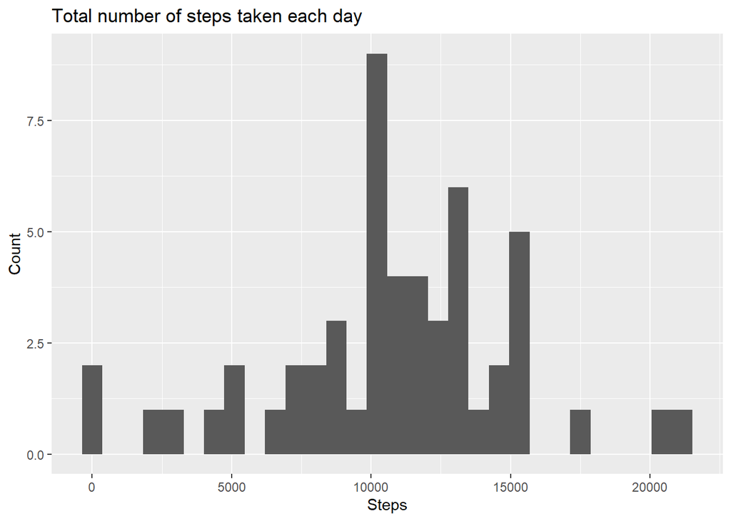

```r
plot1 <- ggplot(steps_per_day, aes(x=steps)) +
  geom_histogram() +
  ggtitle("Total number of steps taken each day") +
  xlab("Steps") +
  ylab("Count")

print(plot1)
```

Calculate and report the mean and median of the total number of steps taken per day:

```r
meansteps <- mean(steps_per_day$steps, na.rm = T)
mediansteps <- median(steps_per_day$steps, na.rm = T)

meansteps
```

```
## [1] 10766.19
```

```r
mediansteps
```

```
## [1] 10765
```

##### **2. What is the average daily activity pattern?**

Make a time series plot (i.e. type = “l”) of the 5-minute interval (x-axis) and the average number of steps taken, averaged across all days (y-axis).

Compute interval average

```r
interval_average <- aggregate(list(Average=activity_raw$steps), by=list(Interval=activity_raw$interval), FUN = mean, na.rm=T)
```

Make an average activity plot:

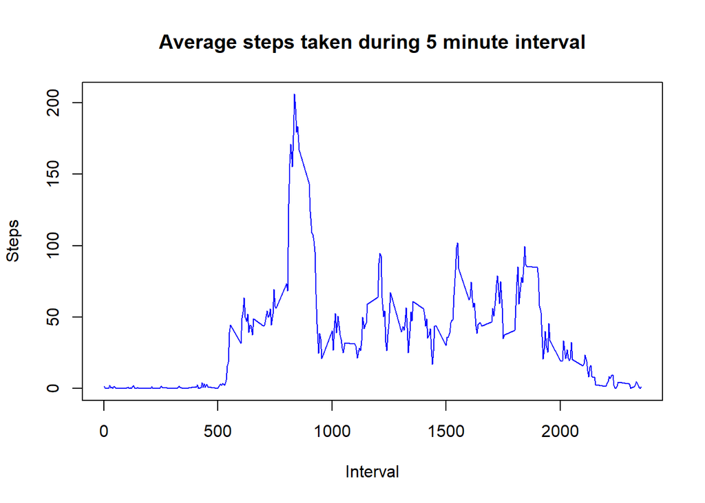

```r
plot2 <- plot(interval_average$Interval, interval_average$Average,
     type="l",
     col="blue",
     xlab="Interval",
     ylab="Steps",
     main="Average steps taken during 5 minute interval")
```

```r
maxstepinterval <- interval_average$Interval[which.max(interval_average$Average)]
```

##### **3. Imputing missing values**

Note that there are a number of days/intervals where there are missing values (coded as NA). The presence of missing days may introduce bias into some calculations or summaries of the data.

```r
na_rows <- sum(is.na(activity_raw$steps))
```

Devise a strategy for filling in all of the missing values in the dataset. The strategy does not need to be sophisticated. For example, you could use the mean/median for that day, or the mean for that 5-minute interval, etc. Create a new dataset that is equal to the original dataset but with the missing data filled in.

```r
activity_processed <- activity_raw

for (i in 1:nrow(activity_processed))
  {
  if (is.na(activity_processed$steps[i]))
    {
    activity_processed$steps[i] <- interval_average[which(activity_processed$interval[i] == interval_average$Interval), ]$Average
    }
  }
```

Make a histogram of the total number of steps taken each day.

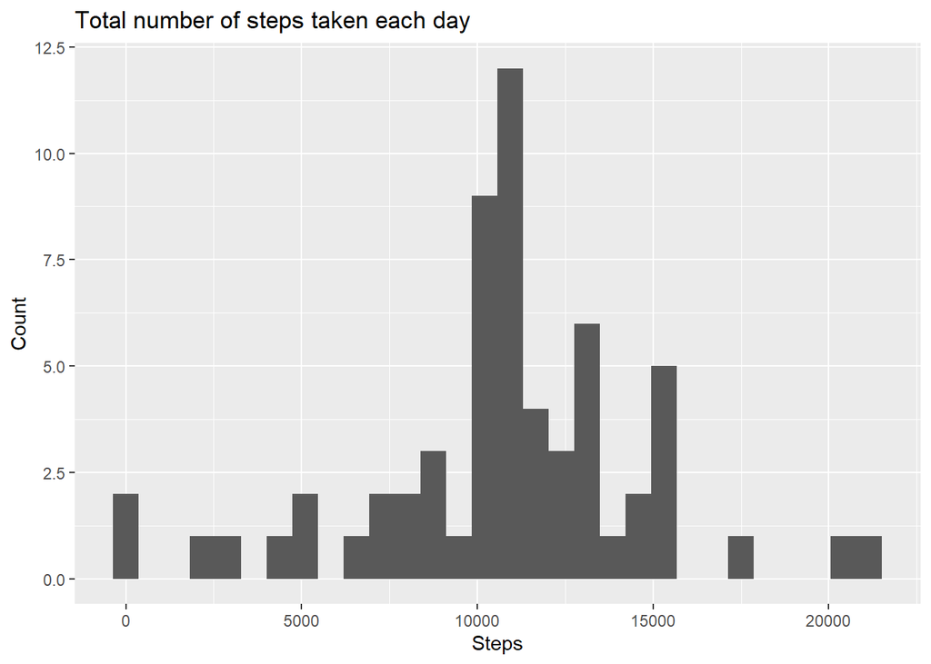

```r
steps_per_day_processed <- aggregate(list(steps = activity_processed$steps),
                                     by=list(date=activity_processed$date),
                                     FUN=sum)


plot3 <- ggplot(steps_per_day_processed, aes(x=steps)) +
  geom_histogram() +
  ggtitle("Total number of steps taken each day") +
  xlab("Steps") +
  ylab("Count")

print(plot3)
```

Calculate and report the mean and median total number of steps taken per day.

```r
meansteps_processed <- mean(steps_per_day_processed$steps)
mediansteps_processed <- median(steps_per_day_processed$steps)

meansteps_processed
```

```
## [1] 10766.19
```

```r
mediansteps_processed
```

```
## [1] 10766.19
```

Do these values differ from the estimates from the first part of the assignment? What is the impact of imputing missing data on the estimates of the total daily number of steps?

*Mean is same as before, median is now equal to mean*

##### **4. Are there differences in activity patterns between weekdays and weekends?**

For this part the weekdays() function may be of some help here. Use the dataset with the filled-in missing values for this part.

```r
activity_processed$datetype <- sapply(activity_processed$date, function(x) {
  if (weekdays(x) == "samedi" | weekdays(x) =="dimanche")
  {
    y <- "Weekend"
  } else
  {
    y <- "Weekday"
  }
  y
})

activity_by_date <- aggregate(steps~interval + datetype, activity_processed, mean, na.rm = TRUE)
```

Make a plot

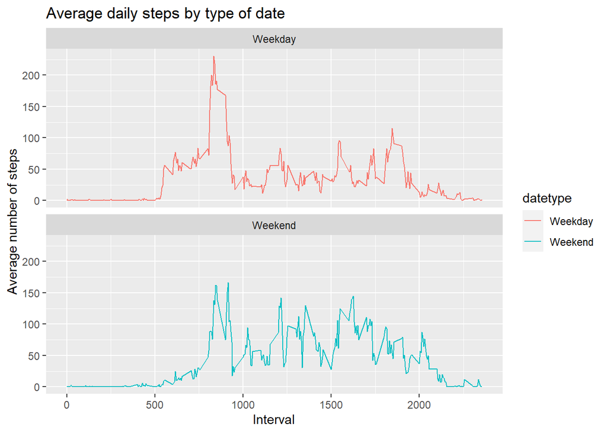

```r
plot4 <- ggplot(activity_by_date, aes(x = interval , y = steps, color = datetype)) +
  geom_line() +
  labs(title = "Average daily steps by type of date", x = "Interval", y = "Average number of steps") +
  facet_wrap(~datetype, ncol = 1, nrow=2)

print(plot4)
```

*Weekdays have a higher actvity in the mornings*